# Rumen bacterial communities can be acclimated faster to high concentrate diets than currently implemented feedlot programs

Christopher L. Anderson (canderson30@unl.edu)

## Data Curation

Raw data is provided in the github repository already, but need to download other files essential to the analysis, including the SILVA v119 reference files. Additionally, here we ‘unbundle’ and install packages that are needed for the analysis with Packrat.

## OTU Picking

Convert the fasta file headers from QIIME format to a format that works with UPARSE to generate the OTU table.

```r
seqs <- readDNAStringSet("qc_trim.rc.fasta", format = "fasta")

names(seqs) <- str_extract(names(seqs), "R\\d+_\\d+") %>%
  str_split("_") %>%
  map_chr(~str_c("rumen", .x[[2]], ";barcode=", .x[[1]]))

writeXStringSet(seqs, "qc_trim_rc_format.fasta", format = "fasta")
```

Use UPARSE suite of tools to pick OTUs.

```bash
gzip -d gold.fasta.gz
mkdir usearch_out

usearch -derep_fulllength qc_trim_rc_format.fasta -sizeout -output usearch_out/derep.fasta

usearch -sortbysize usearch_out/derep.fasta -minsize 2 -output usearch_out/derep_sort.fasta

usearch -cluster_otus usearch_out/derep_sort.fasta -otus usearch_out/otus1.fasta

usearch -uchime_ref usearch_out/otus1.fasta -db gold.fasta -strand plus -nonchimeras usearch_out/otus1_no_chim.fasta

python usearch_python_scripts/fasta_number.py usearch_out/otus1_no_chim.fasta > usearch_out/otus2.fasta

usearch -usearch_global qc_trim_rc_format.fasta -db usearch_out/otus2.fasta -strand plus -id 0.97 -uc usearch_out/otu_map.uc

python usearch_python_scripts/uc2otutab.py usearch_out/otu_map.uc > otu_table.txt
```

## Assign and Summarize Taxonomy

```bash
assign_taxonomy.py -i usearch_out/otus2.fasta -t anaconda/envs/rumenEnv/lib/python2.7/site-packages/qiime_default_reference/gg_13_8_otus/taxonomy/97_otu_taxonomy.txt -r anaconda/envs/rumenEnv/lib/python2.7/site-packages/qiime_default_reference/gg_13_8_otus/rep_set/97_otus.fasta -o assign_taxa -m mothur
```

Add the taxa to the OTU table with the column header “taxonomy” and output the resulting file to biom format.

```bash
awk 'NR==1; NR > 1 {print $0 | "sort"}' otu_table.txt > otu_table_sort.txt

sort assign_taxa/otus2_tax_assignments.txt > assign_taxa/otus2_tax_assignments_sort.txt

{ printf '\ttaxonomy\t\t\n'; cat assign_taxa/otus2_tax_assignments_sort.txt ; }  > assign_taxa/otus2_tax_assignments_sort_label.txt

paste otu_table_sort.txt <(cut -f 2 assign_taxa/otus2_tax_assignments_sort_label.txt) > otu_table_tax.txt

rm otu_table_sort.txt

biom convert --table-type "OTU table" -i otu_table_tax.txt -o otu_table_tax.biom --process-obs-metadata taxonomy --to-json
```

Summarize taxonomy based on those assignments that go to at least the genera and family levels.

```bash
biom convert --table-type "OTU table" -i otu_table_tax_final.biom -o otu_table_tax_final.txt --header-key taxonomy --output-metadata-id "taxonomy" --to-tsv

# summarize by genera
head -n 2 otu_table_tax_final.txt > otu_table_tax_genus.txt

grep "g__[a-zA-Z0-9]" otu_table_tax_final.txt >> otu_table_tax_genus.txt

biom convert --table-type "OTU table" -i otu_table_tax_genus.txt -o otu_table_tax_genus.biom --process-obs-metadata taxonomy --to-json

biom summarize-table -i otu_table_tax_genus.biom -o otu_table_tax_genus_summary.txt

# summarize by family
head -n 2 otu_table_tax_final.txt > otu_table_tax_family.txt

grep "f__[a-zA-Z0-9]" otu_table_tax_final.txt >> otu_table_tax_family.txt

biom convert --table-type "OTU table" -i otu_table_tax_family.txt -o otu_table_tax_family.biom --process-obs-metadata taxonomy --to-json

biom summarize-table -i otu_table_tax_family.biom -o otu_table_tax_family_summary.txt
```

## Filter Reads

Two of the samples were collected and sequenced twice. Unsure sure why, but lets remove the duplicate with the lower depth - samples R6 and R19.

```bash
printf "R6\nR19" > remove_samples.txt

filter_samples_from_otu_table.py -i otu_table_tax.biom -o otu_table_tax_filter.biom --sample_id_fp remove_samples.txt --negate_sample_id_fp

biom summarize-table -i otu_table_tax_filter.biom -o otu_table_tax_filter_summary.txt
```

```r
summary <- read_tsv("otus2.summary")
filtered_otus <- filter(summary, end == 13125 & start > 1726) %>%
  select(seqname)
write_tsv(filtered_otus, "remove_otus.txt", col_names = F)
```

Next, remove those OTUs that did not align well from the OTU table, and additionally, those OTUs with a Cyanobacteria classification. UPARSE should have removed sinlgeton OTUs, but while we are removing OTUs we want to double check this is the case (-n 2 parameter).

```bash
filter_otus_from_otu_table.py -i otu_table_tax_filter.biom -o otu_table_tax_filter2.biom -e remove_otus.txt -n 2 --negate_ids_to_exclude

filter_taxa_from_otu_table.py -i otu_table_tax_filter2.biom -o otu_table_tax_final.biom -n p__Cyanobacteria

biom summarize-table -i otu_table_tax_final.biom -o otu_table_tax_final_summary.txt
```

## Rarefaction Curves and Alpha Diversity

We wanted to look at the sequencing depth of each sample by monitoring the number of novel OTUs encountered as sample depth is increased. Setup here is for a depth roughly equivalent to least sample seqeunced within a step-up diet in our study so we can visually see full depth to give us an idea if the curves were plateauing. Also, here we compare alpha diversity (observed OTUs and chao1 index) with all samples at the sample depth.

Remember, from QIIME notes: “If the lines for some categories do not extend all the way to the right end of the x-axis, that means that at least one of the samples in that category does not have that many sequences.”

```bash
multiple_rarefactions.py -i otu_table_tax_final.biom -o alpha_rare -m 10 -x 6600 -s 500 -n 10

alpha_diversity.py -i alpha_rare/ -o alpha_rare_otu_chao -m observed_otus,chao1

collate_alpha.py -i alpha_rare_otu_chao/ -o alpha_rare_collate

make_rarefaction_plots.py -i alpha_rare_collate/ -m mapping.txt -e stderr --generate_average_tables -b Treatment -w -o alpha_rare_collate_avgtable

multiple_rarefactions_even_depth.py -i otu_table_tax_final.biom -n 10 -d 2160 -o mult_even

alpha_diversity.py -i mult_even/ -o alpha_even -m observed_otus,chao1,goods_coverage

collate_alpha.py -i alpha_even -o alpha_even_collate

alpha_diversity.py -i otu_table_tax_final.biom -o goods.txt -m goods_coverage
```

```r
rare_html <- readHTMLTable("alpha_rare_collate_avgtable/rarefaction_plots.html")
rare_html$rare_data[rare_html$rare_data == "nan"] <- NA
colnames(rare_html$rare_data) <- c("treatment", "seqs", "chao_avg", "chao_err", "otu_avg", "otu_err")
rare_df <- as_tibble(rare_html$rare_data)
rare_df <- rare_df %>%
  mutate_at(vars(-treatment), as.character) %>%
  mutate_at(vars(-treatment), as.double) %>%
  mutate(diet = if_else(str_detect(treatment, "^C"), "Corn", "RAMP")) %>%
  mutate(plot_color = case_when(
    str_detect(treatment, ("[CR]1")) ~ "#FF0000",
    str_detect(treatment, ("[CR]2")) ~ "#BF003F",
    str_detect(treatment, ("[CR]3")) ~ "#7F007F",
    str_detect(treatment, ("[CR]4")) ~ "#3F00BF",
    str_detect(treatment, ("[CR]F")) ~ "#0000FF"
  )) %>%
  group_by(diet)

plot_color_vect <- rare_df$plot_color
names(plot_color_vect) <- rare_df$treatment

rare_otu_plot <- ggplot(rare_df, aes(x = seqs, y = otu_avg, color = treatment, group = treatment, ymin = otu_avg - otu_err, ymax = otu_avg + otu_err)) +
  facet_grid(~diet) +
  geom_line(position = position_dodge(width = 275)) +
  geom_pointrange(position = position_dodge(width = 275), size = 0.3) +
  scale_color_manual(values = plot_color_vect) +
  labs(x = "Sequences per Sample", y = "Mean Observed OTUs") +
  theme(legend.title = element_blank(),
        text = element_text(size = 6))

rare_chao_plot <- ggplot(rare_df, aes(x = seqs, y = chao_avg, color = treatment, group = treatment, ymin = chao_avg - chao_err, ymax = chao_avg + chao_err)) +
  facet_grid(~diet) +
  geom_line(position = position_dodge(width = 275)) +
  geom_pointrange(position = position_dodge(width = 275), size = 0.3) +
  scale_color_manual(values = plot_color_vect) +
  labs(x = "Sequences per Sample", y = "Mean Observed OTUs") +
  theme(legend.title = element_blank(),
        text = element_text(size = 6))

alpha_col_names <- c("CF_332", "R3_259", "R2_343", "R4_343", "R4_259", "C3_346", "C4_332", "R1_222", "CF_346", "RF_343", "RF_222", "C3_332", "R2_222", "R1_343", "R3_343", "C1_346", "C2_332", "R2_259", "R3_222", "C1_332", "C2_346", "R4_222", "RF_259", "R1_259", "C4_346")

alpha_chao <- read_tsv("alpha_even_collate/chao1.txt")
alpha_chao <- select(alpha_chao, starts_with("R"))
names(alpha_chao) <- alpha_col_names
alpha_chao_t <- enframe(as.list(alpha_chao))
alpha_chao_plot <- alpha_chao_t %>%
  mutate(means = map_dbl(value, mean)) %>%
  mutate(sds = map_dbl(value, sd)) %>%
  mutate(diet = if_else(str_detect(name, "^C"), "Corn", "RAMP")) %>%
  mutate(treatment = str_sub(name, 1, 2)) %>%
  ggplot(., aes(x = treatment, y = means)) +
    facet_wrap(~diet) +
    geom_point(size = 2) +
    labs(x = "", y = "Mean Chao1 Index") +
    theme(legend.title = element_blank(),text = element_text(size = 6))

alpha_otu <- read_tsv("alpha_even_collate/observed_otus.txt")
alpha_otu <- select(alpha_otu, starts_with("R"))
names(alpha_otu) <- alpha_col_names
alpha_otu_t <- enframe(as.list(alpha_otu))
alpha_otu_plot <- alpha_otu_t %>%
  mutate(means = map_dbl(value, mean)) %>%
  mutate(sds = map_dbl(value, sd)) %>%
  mutate(diet = if_else(str_detect(name, "^C"), "Corn", "RAMP")) %>%
  mutate(treatment = str_sub(name, 1, 2)) %>%
  ggplot(., aes(x = treatment, y = means)) +
    facet_wrap(~diet) +
    geom_point(size = 2) +
    labs(x = "", y = "Mean Observed OTUs") +
    theme(legend.title = element_blank(),text = element_text(size = 6))

multiplot(rare_otu_plot, rare_chao_plot, alpha_otu_plot, alpha_chao_plot, cols = 2)

pdf("FigureS2.pdf", height = 12, width = 12)
multiplot(rare_otu_plot, rare_chao_plot, alpha_otu_plot, alpha_chao_plot, cols = 2)
dev.off()
```

## Beta Diversity

Investigate the influence of Corn and RAMP based treatments on beta diversity independently.

```bash
biom summarize-table -i otu_table_tax_final.biom -o otu_table_tax_final_summary.txt

beta_diversity_through_plots.py -i otu_table_tax_final.biom -o beta_div -t otus2.phylip.tre -m mapping.txt -p qiime_parameters_working.txt -e 2160

split_otu_table.py -i otu_table_tax_final.biom -o split_total -m mapping.txt -f Diet

biom summarize-table -i split_total/otu_table_tax_final__Diet_Corn__.biom -o split_total/corn_summarize.txt

biom summarize-table -i split_total/otu_table_tax_final__Diet_RAMP__.biom -o split_total/ramp_summarize.txt

beta_diversity_through_plots.py -i split_total/otu_table_tax_final__Diet_Corn__.biom -o corn_beta_div -t otus2.phylip.tre -m mapping.txt -p qiime_parameters_working.txt -e 2160

beta_diversity_through_plots.py -i split_total/otu_table_tax_final__Diet_RAMP__.biom -o ramp_beta_div -t otus2.phylip.tre -m mapping.txt -p qiime_parameters_working.txt -e 2959
```

We use PERMANOVA with the unweighted UNIFRAC distance matrix to identify changes in microbial community structure between treatment groups in those animals fed RAMP and the corn-based diet. Additioanlly, we check that the data does not violate the assumptions of PERMANOVA. However, because there is no variance within the corn-based treatment group due to low sample numbers (that is, within a group there is only one value, i.e. C1-C1 distance, C2-C2 distance, etc.), the results testing a violation of the assumptions of PERMANOVA are unreliable.

```r
set.seed(11)
corn_unweighted <- read_tsv("corn_beta_div/unweighted_unifrac_dm.txt")
corn_unweighted_dist <- corn_unweighted %>%
  select(-X1) %>%
  as.dist(.)

ramp_unweighted <- read_tsv("ramp_beta_div/unweighted_unifrac_dm.txt")
ramp_unweighted_dist <- ramp_unweighted %>%
  select(-X1) %>%
  as.dist(.)

dist_list <- list(corn_unweighted_dist, ramp_unweighted_dist)

mapping <- read_tsv("mapping.txt")
names(mapping)[1] <- "SampleID"
mapping <- mapping %>%
  filter(SampleID != "R6", SampleID != "R19") %>%
  mutate_at(vars(AnimalID, Treatment), as.factor) %>%
  group_by(Diet) %>%
  nest() %>%
  arrange(Diet) %>%
  mutate(dists = dist_list) %>%
  mutate(permanova = map2(dists, data, ~adonis(.x ~ Treatment + AnimalID, permutations = 999, data = .y))) %>%
  mutate(anova_treat = map2(dists, data, ~anova(betadisper(.x, .y$Treatment)))) %>%
  mutate(anova_animal = map2(dists, data, ~anova(betadisper(.x, .y$AnimalID)))) %>%
  mutate(permu_treat = map2(dists, data, ~permutest(betadisper(.x, .y$Treatment)))) %>%
  mutate(permu_animal = map2(dists, data, ~permutest(betadisper(.x, .y$AnimalID))))
```

```r
(corn_perm <- mapping %>%
  filter(Diet == "Corn") %>%
  select(permanova)
)[[1]]
```

```r
(corn_anova_treat <- mapping %>%
  filter(Diet == "Corn") %>%
  select(anova_treat)
)[[1]]
```

```r
(corn_anova_animal <- mapping %>%
  filter(Diet == "Corn") %>%
  select(anova_animal)
)[[1]]
```

```r
(corn_permu_treat <- mapping %>%
  filter(Diet == "Corn") %>%
  select(permu_treat)
)[[1]]
```

```r
(corn_permu_animal <- mapping %>%
  filter(Diet == "Corn") %>%
  select(permu_animal)
)[[1]]
```

```r
(ramp_perm <- mapping %>%
  filter(Diet == "RAMP") %>%
  select(permanova)
)[[1]]
```

```r
(ramp_anova_treat <- mapping %>%
  filter(Diet == "RAMP") %>%
  select(anova_treat)
)[[1]]
```

```r
(ramp_anova_animal <- mapping %>%
  filter(Diet == "RAMP") %>%
  select(anova_animal)
)[[1]]
```

```r
(ramp_permu_treat <- mapping %>%
  filter(Diet == "RAMP") %>%
  select(permu_treat)
)[[1]]
```

```r
(ramp_permu_animal <- mapping %>%
  filter(Diet == "RAMP") %>%
  select(permu_animal)
)[[1]]
```

We used the Mann-Whitney U Test as a post-hoc method to compare the microbial communities at stages within an adaptation program. To do this, we compared the pairwise distances relative to step 1 of adaptation. For instance, to test for a difference in community structure between step 2 and step 3, we compared all the pairwise distances from step 1 samples to step 2 samples (S1-S2) to the distance from step 1 samples to step 3 samples (S1-S3).

```r
corn_unweighted_tidy <- corn_unweighted %>%
  gather(R10:R9, key = S2, value = dist) %>%
  dplyr::rename(S1 = X1) %>%
  mutate(unique_key = paste0(pmin(S1, S2), pmax(S1, S2), sep = "")) %>%
  distinct(unique_key, .keep_all = T) %>%
  select(-unique_key)

mapping <- read_tsv("mapping.txt")
names(mapping)[1] <- "SampleID"

corn_unweighted_tidy <- left_join(corn_unweighted_tidy, mapping, by = c("S1" = "SampleID")) %>%
  select(S1, S2, dist, Treatment) %>%
  dplyr::rename(S1_treatment = Treatment) %>%
  left_join(., mapping, by = c("S2" = "SampleID")) %>%
  dplyr::rename(S2_treatment = Treatment) %>%
  mutate(dist_treatment = map2_chr(S1_treatment, S2_treatment, collapse_treatment)) %>%
  filter(dist != 0) %>%
  select(dist, dist_treatment) %>%
  group_by(dist_treatment) %>%
  nest()

corn_unweighted_tidy %>%
  filter((dist_treatment == "C1-C1") | (dist_treatment == "C1-C2")) %$%
  wilcox.test(data[[1]] %$% dist, data[[2]] %$% dist)
```

```r
corn_unweighted_tidy %>%
  filter((dist_treatment == "C1-C2") | (dist_treatment == "C1-C3")) %$%
  wilcox.test(data[[1]] %$% dist, data[[2]] %$% dist)
```

```r
corn_unweighted_tidy %>%
  filter((dist_treatment == "C1-C3") | (dist_treatment == "C1-C4")) %$%
  wilcox.test(data[[1]] %$% dist, data[[2]] %$% dist)
```

```r
corn_unweighted_tidy %>%
  filter((dist_treatment == "C1-C4") | (dist_treatment == "C1-CF")) %$%
  wilcox.test(data[[1]] %$% dist, data[[2]] %$% dist)
```

```r
ramp_unweighted_tidy <- ramp_unweighted %>%
  gather(R11:R8, key = S2, value = dist) %>%
  dplyr::rename(S1 = X1) %>%
  mutate(unique_key = paste0(pmin(S1, S2), pmax(S1, S2), sep = "")) %>%
  distinct(unique_key, .keep_all = T) %>%
  select(-unique_key)

ramp_unweighted_tidy <- left_join(ramp_unweighted_tidy, mapping, by = c("S1" = "SampleID")) %>%
  select(S1, S2, dist, Treatment) %>%
  dplyr::rename(S1_treatment = Treatment) %>%
  left_join(., mapping, by = c("S2" = "SampleID")) %>%
  dplyr::rename(S2_treatment = Treatment) %>%
  mutate(dist_treatment = map2_chr(S1_treatment, S2_treatment, collapse_treatment)) %>%
  filter(dist != 0) %>%
  select(dist, dist_treatment) %>%
  group_by(dist_treatment) %>%
  nest()

ramp_unweighted_tidy %>%
  filter((dist_treatment == "R1-R1") | (dist_treatment == "R1-R2")) %$%
  wilcox.test(data[[1]] %$% dist, data[[2]] %$% dist)
```

```r
ramp_unweighted_tidy %>%
  filter((dist_treatment == "R1-R2") | (dist_treatment == "R1-R3")) %$%
  wilcox.test(data[[1]] %$% dist, data[[2]] %$% dist)
```

```r
ramp_unweighted_tidy %>%
  filter((dist_treatment == "R1-R3") | (dist_treatment == "R1-R4")) %$%
  wilcox.test(data[[1]] %$% dist, data[[2]] %$% dist)
```

```r
ramp_unweighted_tidy %>%
  filter((dist_treatment == "R1-R4") | (dist_treatment == "R1-RF")) %$%
  wilcox.test(data[[1]] %$% dist, data[[2]] %$% dist)
```

## Shared OTUs and Sequences

First, make venn diagrams dislaying the distribution of OTUs between steup up diets within the RAMP and corn-based treatment.

```bash
collapse_samples.py -b otu_table_tax_family.biom -m mapping.txt --output_biom_fp otu_table_collapse_samples.biom --output_mapping_fp mapping_collapse.txt --collapse_fields Treatment --collapse_mode sum

split_otu_table.py -i otu_table_collapse_samples.biom -m mapping_collapse.txt -f Diet -o split_collapse_samples

biom convert -i split_collapse_samples/otu_table_collapse_samples__Diet_Corn__.biom -o split_collapse_samples/otu_table_collapse_samples__Diet_Corn__.json.biom --to-json --table-type="OTU table"

biom convert -i split_collapse_samples/otu_table_collapse_samples__Diet_RAMP__.biom -o split_collapse_samples/otu_table_collapse_samples__Diet_RAMP__.json.biom --to-json --table-type="OTU table"
```

```r
corn_biom <- read_biom("split_collapse_samples/otu_table_collapse_samples__Diet_Corn__.json.biom")

corn_df <- as_tibble(as(biom_data(corn_biom), "matrix"))
corn_boolean_df <- as_tibble(corn_df > 0) %>%
  select(C1, C2, C3, C4, CF)

corn_venn <- venn(corn_boolean_df)

pdf("Figure4_panelA.pdf", height = 6, width = 6)
corn_venn <- venn(corn_boolean_df)
dev.off()

ramp_biom <- read_biom("split_collapse_samples/otu_table_collapse_samples__Diet_RAMP__.json.biom")

ramp_df <- as_tibble(as(biom_data(ramp_biom), "matrix"))
ramp_boolean_df <- as_tibble(ramp_df > 0) %>%
  select(R1, R2, R3, R4, RF)

ramp_venn <- venn(ramp_boolean_df)

pdf("Figure4_panelB.pdf", height = 6, width = 6)
ramp_venn <- venn(ramp_boolean_df)
dev.off()
```

Get shared number of OTUs and sequences per sample.

```bash
shared_phylotypes.py -i otu_table_collapse_samples.biom -o collapse_samples_shared_otus.txt
```

Write shared number of OTUs between treatments to file.

```r
share_otu <- read_tsv("collapse_samples_shared_otus.txt")

share_otu_tidy <- share_otu %>%
  gather(R4:C4, key = "S2", value = "OTUs") %>%
  dplyr::rename(S1 = X1) %>%
  mutate(unique_key = paste0(pmin(S1, S2), pmax(S1, S2), sep = "")) %>%
  distinct(unique_key, .keep_all = T) %>%
  select(-unique_key) %>%
  filter(S1 != S2) %>%
  mutate(max_share = map2_int(S1, S2, max_shared_otu)) %>%
  mutate(per_share = (OTUs / max_share) * 100) %>%
  select(S1, S2, OTUs, per_share) %>%
  write_tsv("Table_S4.txt", col_names = F)
```

Write shared number of sequences between treatments to file.

```r
collapse_biom <- read_biom("otu_table_collapse_samples.biom")
collapse_df <- as_data_frame(as(biom_data(collapse_biom), "matrix"))
collapse_tib <- as_tibble(rownames_to_column(collapse_df))
collapse_tidy <- collapse_tib %>%
  dplyr::rename(otu = rowname) %>%
  gather(R4:C4, key = "sample", value = "abundance") %>%
  filter(abundance > 0) %>%
  group_by(sample) %>%
  nest()

combn_output <- combn(unique(collapse_tidy$sample), 2, simplify = FALSE, FUN = seq_shared)
```

## OTU Heatmap

```r
otu_table_biom <- read_biom("otu_table_tax_final.biom")
otu_table <- as_data_frame(as(biom_data(otu_table_biom), "matrix"))
row.names(otu_table) <- otu_table$OTU.ID
colnames(otu_table) <- c("CF_332", "R3_259", "R2_343", "R4_343", "R4_259", "C3_346", "C4_332", "R1_222", "CF_346", "RF_343", "RF_222", "C3_332", "R2_222", "R1_343", "R3_343", "C1_346", "C2_332", "R2_259", "R3_222", "C1_332", "C2_346", "R4_222", "RF_259", "R1_259", "C4_346")
otu_table_trans <- as_data_frame(t(otu_table))
otu_table_rel <- otu_table_trans/rowSums(otu_table_trans)
scalewhiteblack <- colorRampPalette(c("white", "black"), space = "rgb")(100)
otu_dist <- vegdist(otu_table_rel, method = "bray")
row.clus <- hclust(otu_dist, "aver")
maxab <- apply(otu_table_rel, 2, max)
n1 <- names(which(maxab < 0.01))
otu_table_rel2 <- otu_table_rel[, -which(names(otu_table_rel) %in% n1)]
otu_dist_col <- vegdist(t(otu_table_rel2), method = "bray")
col.clus <- hclust(otu_dist_col, "aver")
png("Figure2.png", units = 'in', height = 8, width = 8, res = 600)
heatmap.2(as.matrix(otu_table_rel2), Rowv = as.dendrogram(row.clus), Colv = as.dendrogram(col.clus), col = scalewhiteblack, margins = c(2, 6), trace = "none", density.info = "none", labCol = "", xlab = "OTUs", ylab = "Samples", main = "", lhei = c(2, 8))
dev.off()
```

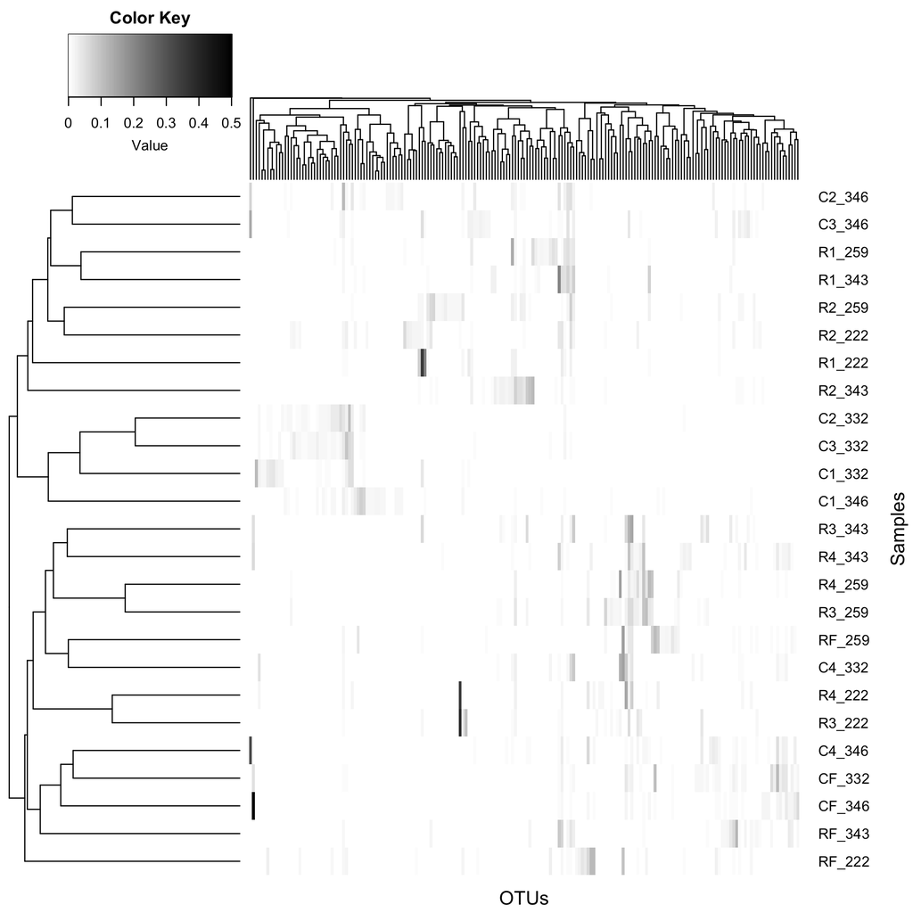

## Pairwise Comparisons and Principle Component Analysis

```r
corn_distance_plot <- corn_unweighted_tidy %>%
  filter(str_detect(dist_treatment, "^C1-")) %>%
  unnest() %>%
  ggplot(., aes(x = dist_treatment, y = dist)) +
    geom_boxplot() +
    geom_point(position = position_jitter(width = 0.15)) +
    labs(x = "", y = "Unweighted UniFrac Distance\n") +
    guides(fill = FALSE) +
    theme(axis.text.x = element_text(colour = "black"),
          axis.title.y = element_text(size = 14),
          axis.ticks = element_blank())

ramp_distance_plot <- ramp_unweighted_tidy %>%
  filter(str_detect(dist_treatment, "^R1-")) %>%
  unnest() %>%
  ggplot(., aes(x = dist_treatment, y = dist)) +
    geom_boxplot() +
    geom_point(position = position_jitter(width = 0.15)) +
    labs(x = "", y = "Unweighted UniFrac Distance\n") +
    guides(fill = FALSE) +
    theme(axis.text.x = element_text(colour = "black"),
          axis.title.y = element_text(size = 14),
          axis.ticks = element_blank())

shape_plot <- c("R1" = 15, "R2" = 16, "R3" = 17, "R4" = 18, "RF" = 8, "C1" = 15, "C2" = 16, "C3" = 17, "C4" = 18, "CF" = 8)
color_plot <- c("R1" = "red", "R2" = "red", "R3" = "red", "R4" = "red", "RF" = "red", "C1" = "blue", "C2" = "blue", "C3" = "blue", "C4" = "blue", "CF" = "blue")
con <- file("beta_div/unweighted_unifrac_pc.txt")
pc <- read_tsv(con, skip = 9, n_max = 25, col_names = F)
pc_plot <- pc %>%
  rename(SampleID = X1, PC1 = X2, PC2 = X3) %>%
  left_join(., mapping, by = "SampleID") %>%
  select(SampleID, PC1, PC2, Treatment) %>%
  ggplot(., aes(PC1, PC2)) +
    geom_point(aes(size=4, color = factor(Treatment), shape = factor(Treatment))) +
    xlab("PC1 (21.1%)") + ylab("PC2 (10.0%)") +
    guides(size = FALSE) +
    scale_shape_manual(name = "", values = shape_plot) +
    scale_colour_manual(name = "", values = color_plot) +
    labs(fill = "")

multiplot(pc_plot, corn_distance_plot, ramp_distance_plot, cols = 3)

pdf("Figure1.pdf", height = 6, width = 16)
multiplot(pc_plot, corn_distance_plot, ramp_distance_plot, cols = 3)
dev.off()
```

## OTU-Level Statistics and Comparisons

Here, we use LEFSE to identify OTUs that differed between treatments at potential break points in microbial community structure found above (i.e. from steps C3 to C4, R1 to R2, and R2 to R3). First, we need to format a file suitable for input into LEFSE.

```bash
# remove potential singleton OTUs
filter_otus_from_otu_table.py -i split_total/otu_table_tax_final__Diet_Corn__.biom -n 1 -o split_total/otu_table_tax_final__Diet_Corn__filter.biom

filter_otus_from_otu_table.py -i split_total/otu_table_tax_final__Diet_RAMP__.biom -n 1 -o split_total/otu_table_tax_final__Diet_RAMP__filter.biom
```

```r
corn_biom <- read_biom("split_total/otu_table_tax_final__Diet_Corn__filter.biom")
corn_table <- as_data_frame(as(biom_data(corn_biom), "matrix"))
corn_rel <- sweep(corn_table, 2, colSums(corn_table), FUN = "/")
rownames(corn_rel) <- paste("OTU", rownames(corn_rel), sep = "")
corn_rel2 <- corn_rel[0, ]
corn_rel2[nrow(corn_rel2) + 1, ] <- c("break2", "break1", "break2", "break2", "break1", "break1", "break1", "break1", "break1", "break2")
corn_rel2[nrow(corn_rel2) + 1, ] <- c("A332", "A346", "A332", "A346", "A332", "A346", "A332", "A332", "A346", "A346")
row.names(corn_rel2) <- c("break", "animal")
corn_rel_merge <- rbind(corn_rel2, corn_rel)
write.table(corn_rel_merge, sep = "\t", file = "split_total/otu_table_tax_final__Diet_Corn__filter_relative.txt", row.names = TRUE, col.names = FALSE, quote = FALSE)

ramp_biom <- read_biom("split_total/otu_table_tax_final__Diet_RAMP__filter.biom")
ramp_table <- as_data_frame(as(biom_data(ramp_biom), "matrix"))
ramp_rel <- sweep(ramp_table, 2, colSums(ramp_table), FUN="/")
rownames(ramp_rel) <- paste("OTU", rownames(ramp_rel), sep="")
ramp_rel2 <- ramp_rel[0,]
ramp_rel2[nrow(ramp_rel2) + 1, ] <- c( "break3", "break2", "break3", "break3", "break1", "break3", "break3", "break2", "break1", "break3", "break2", "break3", "break2", "break3", "break1")
ramp_rel2[nrow(ramp_rel2) + 1, ] <- c( "A259", "A343", "A343", "A259", "A222", "A343", "A222", "A222", "A343", "A343", "A259", "A222", "A222", "A259", "A259")
row.names(ramp_rel2) <- c("break","animal")
ramp_rel_merge <- rbind(ramp_rel2,ramp_rel)
ramp_rel_merge_1 <- subset(ramp_rel_merge, select = c(R18, R24, R8, R12, R23, R5))
ramp_rel_merge_2 <- subset(ramp_rel_merge, select=c(R12, R23, R5, R11, R13, R14, R20, R21, R23, R3, R4, R7))
write.table(ramp_rel_merge_1, sep="\t", file="split_total/otu_table_tax_final__Diet_RAMP__filter_b12_relative.txt", row.names=TRUE, col.names=FALSE, quote = FALSE)
write.table(ramp_rel_merge_2, sep="\t", file="split_total/otu_table_tax_final__Diet_RAMP__filter_b23_relative.txt", row.names=TRUE, col.names=FALSE, quote = FALSE)
```

Run LEFSE.

```bash
wget https://bitbucket.org/nsegata/lefse/get/default.zip -O lefse.zip
unzip lefse.zip
mv nsegata* lefse

python lefse/format_input.py split_total/otu_table_tax_final__Diet_Corn__filter_relative.txt corn_lefse_format.txt -c 1 -u 2 -o 1000000
python lefse/run_lefse.py corn_lefse_format.txt corn_lefse_result.txt

python lefse/format_input.py split_total/otu_table_tax_final__Diet_RAMP__filter_b12_relative.txt ramp_12_lefse_format.txt -c 1 -u 2 -o 1000000
python lefse/run_lefse.py ramp_12_lefse_format.txt ramp_12_lefse_result.txt

python lefse/format_input.py split_total/otu_table_tax_final__Diet_RAMP__filter_b23_relative.txt ramp_23_lefse_format.txt -c 1 -u 2 -o 1000000
python lefse/run_lefse.py ramp_23_lefse_format.txt ramp_23_lefse_result.txt
```

```r
corn_lefse <- read_tsv("corn_lefse_result.txt", col_names = F)
corn_lefse %>%
  filter(X4 != "NA") %>%
  mutate(X1 = str_replace(X1, "OTU", "")) %$%
  write(X1, "corn_lefse_otus.txt")

ramp_12_lefse <- read_tsv("ramp_12_lefse_result.txt", col_names = F)
ramp_12_lefse %>%
  filter(X4 != "NA") %>%
  mutate(X1 = str_replace(X1, "OTU", "")) %$%
  write(X1, "ramp_12_lefse_otus.txt")

ramp_23_lefse <- read_tsv("ramp_23_lefse_result.txt", col_names = F)
ramp_23_lefse %>%
  filter(X4 != "NA") %>%
  mutate(X1 = str_replace(X1, "OTU", "")) %$%
  write(X1, "ramp_23_lefse_otus.txt")
```

```bash
filter_otus_from_otu_table.py -i split_total/otu_table_tax_final__Diet_Corn__filter.biom -o corn_lefse.biom -e corn_lefse_otus.txt --negate_ids_to_exclude
biom convert -i corn_lefse.biom -o corn_lefse.txt --table-type="OTU table" --to-tsv --header-key taxonomy

filter_otus_from_otu_table.py -i split_total/otu_table_tax_final__Diet_RAMP__filter.biom -o ramp_12_lefse.biom -e ramp_12_lefse_otus.txt --negate_ids_to_exclude
biom convert -i ramp_12_lefse.biom -o  ramp_12_lefse.txt --table-type="OTU table" --to-tsv --header-key taxonomy

filter_otus_from_otu_table.py -i split_total/otu_table_tax_final__Diet_RAMP__filter.biom -o ramp_23_lefse.biom -e ramp_23_lefse_otus.txt --negate_ids_to_exclude
biom convert -i ramp_23_lefse.biom -o  ramp_23_lefse.txt --table-type="OTU table" --to-tsv --header-key taxonomy

biom convert -i split_total/otu_table_tax_final__Diet_Corn__filter.biom -o split_total/otu_table_tax_final__Diet_Corn__filter.txt --table-type "OTU table" --to-tsv --header-key taxonomy --output-metadata-id "taxonomy"

biom convert -i split_total/otu_table_tax_final__Diet_RAMP__filter.biom -o split_total/otu_table_tax_final__Diet_RAMP__filter.txt --table-type "OTU table" --to-tsv --header-key taxonomy --output-metadata-id "taxonomy"
```

One shift in the microbial community was identified in the corn-adaptation program. Here, we plot the heatmap for OTUs identified as having a significantly different abundance around this shift. The resulting heatmap only displays OTUs with a maximum relative abundance >1% and are sorted by LDA score.

Corn-based treatment first.

```r
corn_otu <- read_tsv("corn_lefse.txt", skip = 1)
names(corn_otu)[1] <- "OTUID"
corn_fams <- corn_otu %>%
  mutate(family = str_extract(taxonomy, "(?<=f__)[\\[\\]\\w\\d]+")) %>%
  mutate(family = str_replace_all(family, "[\\[\\]]", "")) %>%
  mutate(family = str_replace_na(family, replacement = "No Assigned Family")) %>%
  select(OTUID, family)

corn_lefse <- read_tsv("corn_lefse_result.txt", col_names = F)
corn_lefse <- corn_lefse %>%
  dplyr::rename(OTUID = X1, raw = X2, breaks = X3, LDA = X4, pval = X5) %>%
  mutate(OTUID = as.integer(str_replace(OTUID, "OTU", ""))) %>%
  left_join(corn_fams, ., by = "OTUID") %>%
  arrange(breaks, desc(LDA)) %>%
  write_tsv("Table_S2-1.txt")

corn_table <- read_tsv("split_total/otu_table_tax_final__Diet_Corn__filter.txt", skip = 1)
names(corn_table)[1] <- "OTUID"

corn_otu_lefse <- corn_table %>%
  rename(CF_332 = R10, C3_346 = R15, C4_332 = R16, CF_346 = R2, C3_332 = R22, C1_346 = R36, C2_332 = R37, C1_332 = R40, C2_346 = R41, C4_346 = R9) %>%
  select(OTUID, C1_346, C1_332, C2_346, C2_332, C3_346, C3_332, C4_346, C4_332, CF_346, CF_332)  %>%
  mutate_each(funs(normalize_table), -OTUID) %>%
  gather(C1_346:CF_332, key = sample, value = abundance) %>%
  group_by(OTUID) %>%
  filter(any(abundance > 0.01)) %>%
  ungroup() %>%
  spread(key = sample, value = abundance) %>%
  mutate(OTUID = as.integer(OTUID)) %>%
  inner_join(corn_lefse, by = "OTUID") %>%
  arrange(breaks, desc(LDA))

scalewhiteblack <- colorRampPalette(c("white", "black"), space = "rgb")(100)
lmat = rbind(c(4,0,0),c(2,1,3))
lwid = c(0.60,1.9,0.3)
lhei = c(0.3,1.5)

pdf("Figure3_panelA.pdf", width = 12, height = 9)
corn_otu_lefse %>%
  select(starts_with("C", ignore.case = F)) %>%
  t() %>%
  heatmap.2(Rowv = F, Colv = F, col = scalewhiteblack, margins = c(13, 9.5), trace = "none", density.info = "none", xlab = "", ylab = "", main = "", srtCol = 67.5, cexCol = 1.3, cexRow = 2.0, lmat = lmat, lwid = lwid, lhei = lhei, labCol = corn_otu_lefse$family)
dev.off()
```

Same thing, but plotting differentially abundant OTUs around the two shift in microbial community identified in the RAMP adaptation treatment.

```r
# first microbial shift between steps 1 and 2
ramp_12_otu <- read_tsv("ramp_12_lefse.txt", skip = 1)
names(ramp_12_otu)[1] <- "OTUID"
ramp_12_fams <- ramp_12_otu %>%
  mutate(family = str_extract(taxonomy, "(?<=f__)[\\[\\]\\w\\d]+")) %>%
  mutate(family = str_replace_all(family, "[\\[\\]]", "")) %>%
  mutate(family = str_replace_na(family, replacement = "No Assigned Family")) %>%
  select(OTUID, family)

ramp_12_lefse <- read_tsv("ramp_12_lefse_result.txt", col_names = F)
ramp_12_lefse <- ramp_12_lefse %>%
  dplyr::rename(OTUID = X1, raw = X2, breaks = X3, LDA = X4, pval = X5) %>%
  mutate(OTUID = as.integer(str_replace(OTUID, "OTU", ""))) %>%
  left_join(ramp_12_fams, ., by = "OTUID") %>%
  arrange(breaks, desc(LDA)) %>%
  write_tsv("Table_S2-2.txt")

ramp_table <- read_tsv("split_total/otu_table_tax_final__Diet_RAMP__filter.txt", skip = 1)
names(ramp_table)[1] <- "OTUID"
ramp_12_otu_lefse <- ramp_table %>%
  rename(R3_259 = R11, R2_343 = R12, R4_343 = R13, R4_259 = R14, R1_222 = R18, RF_343 = R20, RF_222 = R21, R2_222 = R23, R1_343 = R24, R3_343 = R3, R2_259 = R38, R3_222 = R4, R4_222 = R5, RF_259 = R7, R1_259 = R8) %>%
  select(OTUID, R1_222, R1_259, R1_343, R2_222, R2_259, R2_343)  %>%
  mutate_each(funs(normalize_table), -OTUID) %>%
  gather(R1_222:R2_343, key = sample, value = abundance) %>%
  group_by(OTUID) %>%
  filter(any(abundance > 0.01)) %>%
  ungroup() %>%
  spread(key = sample, value = abundance) %>%
  mutate(OTUID = as.integer(OTUID)) %>%
  inner_join(ramp_12_lefse, by = "OTUID") %>%
  arrange(breaks, desc(LDA))

scalewhiteblack <- colorRampPalette(c("white", "black"), space = "rgb")(100)
lmat = rbind(c(4,0,0),c(2,1,3))
lwid = c(0.60,1.9,0.3)
lhei = c(0.3,1.5)

pdf("Figure3_panelB.pdf", width = 12, height = 9)
ramp_12_otu_lefse %>%
  select(starts_with("R", ignore.case = F)) %>%
  t() %>%
  heatmap.2(Rowv = F, Colv = F, col = scalewhiteblack, margins = c(13, 9.5), trace = "none", density.info = "none", xlab = "", ylab = "", main = "", srtCol = 67.5, cexCol = 1.3, cexRow = 2.0, lmat = lmat, lwid = lwid, lhei = lhei, labCol = ramp_12_otu_lefse$family)
dev.off()


# second microbial shift between steps 2 and 3/4/F
ramp_23_otu <- read_tsv("ramp_23_lefse.txt", skip = 1)
names(ramp_23_otu)[1] <- "OTUID"
ramp_23_fams <- ramp_23_otu %>%
  mutate(family = str_extract(taxonomy, "(?<=f__)[\\[\\]\\w\\d]+")) %>%
  mutate(family = str_replace_all(family, "[\\[\\]]", "")) %>%
  mutate(family = str_replace_na(family, replacement = "No Assigned Family")) %>%
  select(OTUID, family)

ramp_23_lefse <- read_tsv("ramp_23_lefse_result.txt", col_names = F)
ramp_23_lefse <- ramp_23_lefse %>%
  dplyr::rename(OTUID = X1, raw = X2, breaks = X3, LDA = X4, pval = X5) %>%
  mutate(OTUID = as.integer(str_replace(OTUID, "OTU", ""))) %>%
  left_join(ramp_23_fams, ., by = "OTUID") %>%
  arrange(breaks, desc(LDA)) %>%
  write_tsv("Table_S2-3.txt")

ramp_23_otu_lefse <- ramp_table %>%
  rename(R3_259 = R11, R2_343 = R12, R4_343 = R13, R4_259 = R14, R1_222 = R18, RF_343 = R20, RF_222 = R21, R2_222 = R23, R1_343 = R24, R3_343 = R3, R2_259 = R38, R3_222 = R4, R4_222 = R5, RF_259 = R7, R1_259 = R8) %>%
  select(OTUID, R2_222, R2_259, R2_343, R3_222, R3_259, R3_343, R4_222, R4_259, R4_343, RF_222, RF_259, RF_343)  %>%
  mutate_each(funs(normalize_table), -OTUID) %>%
  gather(R2_222:RF_343, key = sample, value = abundance) %>%
  group_by(OTUID) %>%
  filter(any(abundance > 0.01)) %>%
  ungroup() %>%
  spread(key = sample, value = abundance) %>%
  mutate(OTUID = as.integer(OTUID)) %>%
  inner_join(ramp_23_lefse, by = "OTUID") %>%
  arrange(breaks, desc(LDA))

scalewhiteblack <- colorRampPalette(c("white", "black"), space = "rgb")(100)
lmat = rbind(c(4,0,0),c(2,1,3))
lwid = c(0.60,1.9,0.3)
lhei = c(0.3,1.5)

pdf("Figure3_panelC.pdf", width = 12, height = 9)
ramp_23_otu_lefse %>%
  select(starts_with("R", ignore.case = F)) %>%
  t() %>%
  heatmap.2(Rowv = F, Colv = F, col = scalewhiteblack, margins = c(13, 9.5), trace = "none", density.info = "none", xlab = "", ylab = "", main = "", srtCol = 67.5, cexCol = 1.3, cexRow = 2.0, lmat = lmat, lwid = lwid, lhei = lhei, labCol = ramp_23_otu_lefse$family)
dev.off()
```